# Predicting oil and gas well abandonment

## Exploratory analysis

Before we begin modeling, we’ll visually assess some of the relationships between the variables in question.

### Visualize some distributions

Let’s start by taking a peek at the relationship between orphan status and well depth.

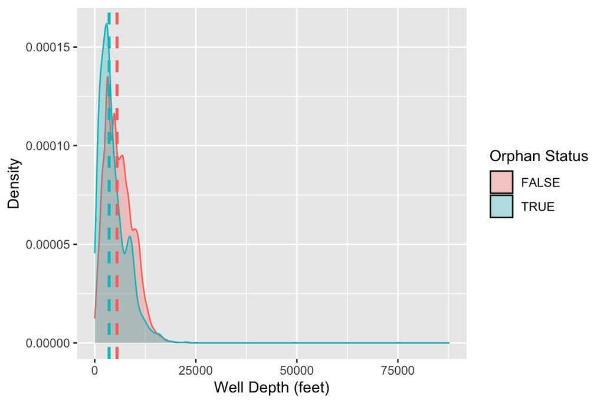

```r
muDepth <- plyr::ddply(inactive,
                 "Is.Orphan.",
                 summarise,
                 grp.med=median(API.Depth,
                                na.rm=TRUE))

ggplot(inactive, aes(API.Depth,
                     fill=Is.Orphan.,
                     color=Is.Orphan.)) +
  labs(fill="Orphan Status") +
  geom_density(alpha=0.3,
               adjust=1.3) +
  geom_vline(data=muDepth,
             aes(xintercept=grp.med,
                 color=Is.Orphan.),
             linetype="dashed",
             size=1) +
  guides(color=FALSE) +
  xlab("Well Depth (feet)") +
  ylab("Density")
```

That’s kind of interesting. Seems like there’s a pretty long tail here, but broadly speaking, it looks like orphaned wells tend to be a bit shallower than merely inactive wells, all else equal.

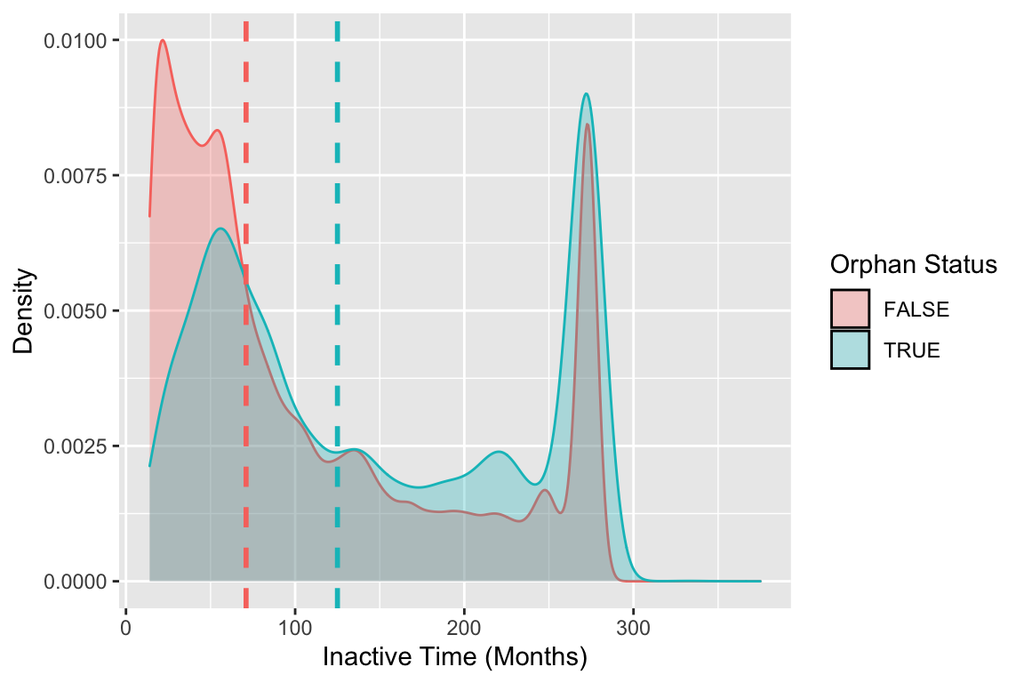

```r
inactive$inactiveTotalMonths <- (inactive$Current.Inactive.Years * 12) + inactive$Current.Inactive.Months
muInactiveMonths <- plyr::ddply(inactive,
                          "Is.Orphan.",
                          summarise,
                          grp.med=median(inactiveTotalMonths,
                                         na.rm=TRUE))

ggplot(inactive,
       aes(inactiveTotalMonths,
           fill=Is.Orphan.,
           color=Is.Orphan.)) +
  labs(fill="Orphan Status") +
  geom_density(alpha=0.3,
               adjust=0.7) +
  geom_vline(data=muInactiveMonths,
             aes(xintercept=grp.med,
                 color=Is.Orphan.),
             linetype="dashed",
             size=1) +
  guides(color=FALSE) +
  xlab("Inactive Time (Months)") +
  ylab("Density")
```

While the big spike near the end of the distribution is probably a database artifact, the broadly overlapping distributions suggest that a bunch of inactive wells have indeed been inactive for just as long as their orphaned peers—and perhaps ought to be considered as such. More on that later…

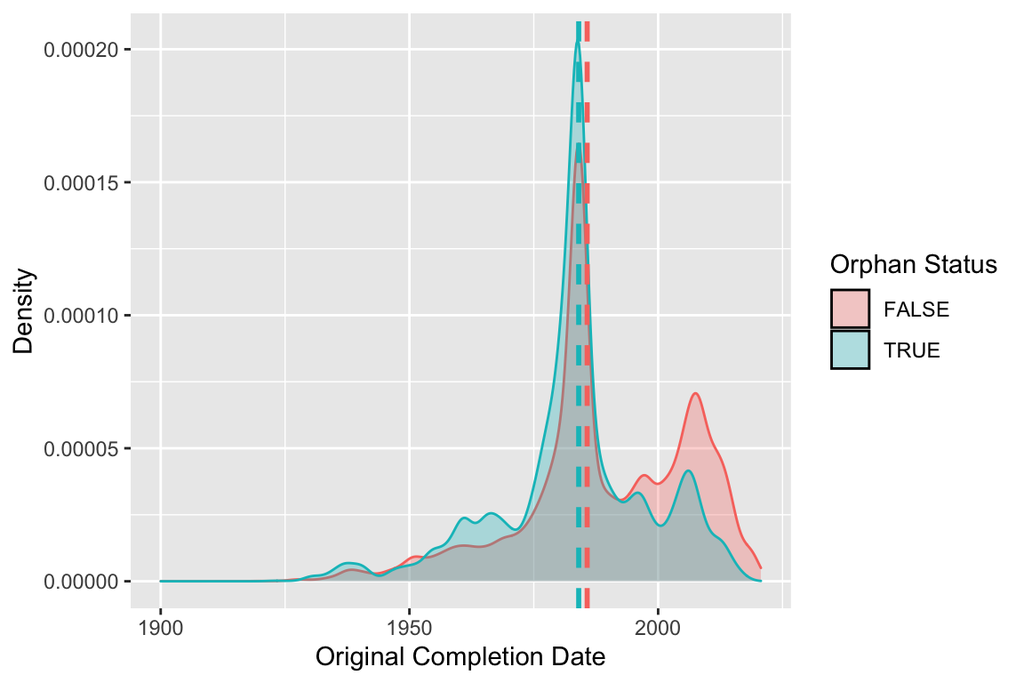

```r
inactive$Original.Completion.Date <- as.Date(as.character(inactive$Original.Completion.Date),
                                             "%Y%m%d")

muOriginalCompletion <- plyr::ddply(inactive,
                              "Is.Orphan.",
                              summarise,
                              grp.med=median(Original.Completion.Date,
                                             na.rm=TRUE))

ggplot(inactive,
       aes(Original.Completion.Date,
           fill=Is.Orphan.,
           color=Is.Orphan.)) +
  labs(fill="Orphan Status") +
  geom_density(alpha=0.3,
               adjust=1) +
  geom_vline(data=muOriginalCompletion,
             aes(xintercept=grp.med,
                 color=Is.Orphan.),
             linetype="dashed",
             size=1) +
  guides(color=FALSE) +
  xlab("Original Completion Date") +
  ylab("Density")
```

(Also probably unsurprising.)

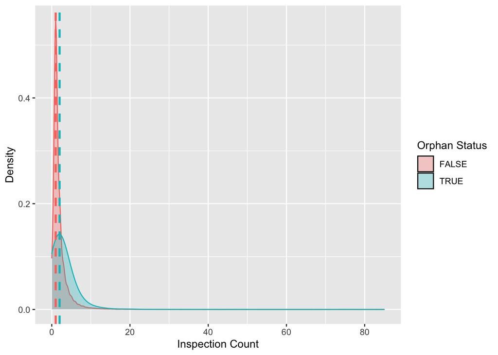

```r
regCounts <- data.frame(API = apiList)
iC <- plyr::count(inspections,
            vars = "API_NO")
vC <- plyr::count(violations,
            vars = "API_NO")
regCounts <- regCounts %>% merge(iC,
                                 by.x = "API",
                                 by.y = "API_NO",
                                 all.x = TRUE)
regCounts <- regCounts %>% merge(vC,
                                 by.x = "API",
                                 by.y = "API_NO",
                                 all.x = TRUE)
colnames(regCounts) <- c("API",
                         "inspectionCount",
                         "violationCount")
regCounts[is.na(regCounts)] <- 0

dI <- inactive %>% merge(regCounts,
                         by = "API",
                         all.x = TRUE)

muiC <- plyr::ddply(dI,
              "Is.Orphan.",
              summarise,
              grp.med=median(inspectionCount,
                             na.rm=TRUE))

ggplot(dI,
       aes(inspectionCount,
           fill=Is.Orphan.,
           color=Is.Orphan.)) +
  labs(fill="Orphan Status") +
  geom_density(alpha=0.3,
               adjust=6) +
  geom_vline(data=muiC,
             aes(xintercept=grp.med,
                 color=Is.Orphan.),
             linetype="dashed",
             size=1) +
  guides(color=FALSE) +
  xlab("Inspection Count") +
  ylab("Density")
```

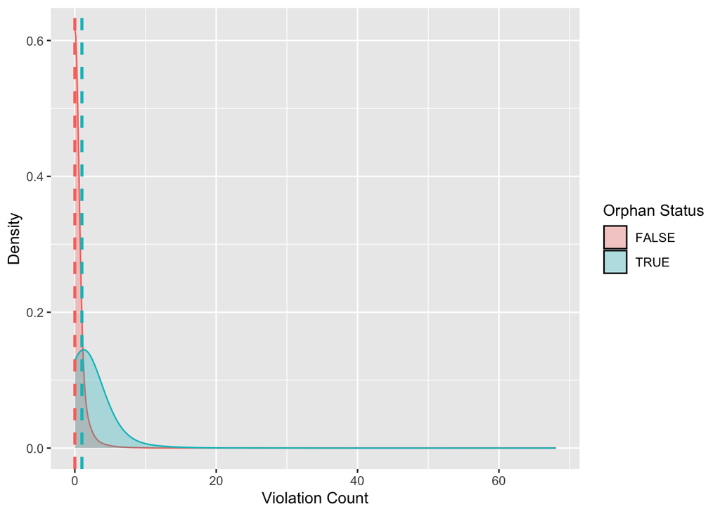

```r
muvC <- plyr::ddply(dI,
              "Is.Orphan.",
              summarise,
              grp.med=median(violationCount,
                             na.rm=TRUE))

ggplot(dI,
       aes(violationCount,
           fill=Is.Orphan.,
           color=Is.Orphan.)) +
  labs(fill="Orphan Status") +
  geom_density(alpha=0.3,
               adjust=6) +
  geom_vline(data=muvC,
             aes(xintercept=grp.med,
                 color=Is.Orphan.),
             linetype="dashed",
             size=1) +
  guides(color=FALSE) +
  xlab("Violation Count") +
  ylab("Density")
```

We’ll deal with those tails later. In the meantime, let’s finish cleaning the dataset, transform a couple variables, and look at a basic logistic regression.

### Unregularized models

```r
dI <- dI %>% merge(operators,
                   by = "Operator.Number",
                   all.x = TRUE)

macroAll$Area <- tolower(macroAll$Area) %>% trimws() %>% as.factor()
mappings$County <- tolower(mappings$County) %>% trimws() %>% as.factor()
dI$County.Name <- tolower(dI$County.Name) %>% trimws() %>% as.factor()

macroAll <- macroAll %>% merge(mappings,
                                by.x = "Area",
                                by.y = "County",
                                all.x = TRUE)

dI <- dI %>% merge(leasesAgg,
                   by.x = c("LEASE","Operator.Number"),
                   by.y = c("LEASE","OPERATOR_NO"),
                   all.x = TRUE)
# pre-inactivity dates
dI$inactiveDate <- as.Date("2020/10/01") %m-% months(dI$inactiveTotalMonths)
dI$inactiveDate3 <- dI$inactiveDate %m-% months(3)
dI$inactiveDate6 <- dI$inactiveDate %m-% months(6)
dI$inactiveDate12 <- dI$inactiveDate %m-% months(12)
dI$inactiveDate18 <- dI$inactiveDate %m-% months(18)
dI$inactiveDate24 <- dI$inactiveDate %m-% months(24)
# post-inactivity dates (we label 'p')
dI$inactiveDate3p <- dI$inactiveDate %m+% months(3)
dI$inactiveDate6p <- dI$inactiveDate %m+% months(6)
dI$inactiveDate12p <- dI$inactiveDate %m+% months(12)

rn <- function(d,t,s){ # data, tail extent, suffix
  colnames(d) <- c(head(colnames(d),length(colnames(d))-t),
                  paste0(tail(colnames(d),t),".",s))
  return(d)
}
# hard-coding in the renaming tail extent for now
renames <- 12

dI <- dI %>% merge(macroAll,
                   by.x = c("inactiveDate","County.Name"),
                   by.y = c("date","Area"),
                   all.x = TRUE)
dI <- rn(dI,renames,"current")

dI <- dI %>% merge(macroAll,
                   by.x = c("inactiveDate3","County.Name"),
                   by.y = c("date","Area"),
                   all.x = TRUE)
dI <- rn(dI,renames,"3")

dI <- dI %>% merge(macroAll,
                   by.x = c("inactiveDate6","County.Name"),
                   by.y = c("date","Area"),
                   all.x = TRUE)
dI <- rn(dI,renames,"6")

dI <- dI %>% merge(macroAll,
                   by.x = c("inactiveDate12","County.Name"),
                   by.y = c("date","Area"),
                   all.x = TRUE)
dI <- rn(dI,renames,"12")

dI <- dI %>% merge(macroAll,
                   by.x = c("inactiveDate18","County.Name"),
                   by.y = c("date","Area"),
                   all.x = TRUE)
dI <- rn(dI,renames,"18")

dI <- dI %>% merge(macroAll,
                   by.x = c("inactiveDate24","County.Name"),
                   by.y = c("date","Area"),
                   all.x = TRUE)
dI <- rn(dI,renames,"24")

dI <- dI %>% merge(macroAll,
                   by.x = c("inactiveDate3p","County.Name"),
                   by.y = c("date","Area"),
                   all.x = TRUE)
dI <- rn(dI,renames,"3p")

dI <- dI %>% merge(macroAll,
                   by.x = c("inactiveDate6p","County.Name"),
                   by.y = c("date","Area"),
                   all.x = TRUE)
dI <- rn(dI,renames,"6p")

dI <- dI %>% merge(macroAll,
                   by.x = c("inactiveDate12p","County.Name"),
                   by.y = c("date","Area"),
                   all.x = TRUE)
dI <- rn(dI,renames,"12p")
# guess we could have done that with a function, huh

# some normalized variables for testing later
dI <- dI %>% mutate(totprod = scale(sumOil)+scale(sumGas))
dI <- dI %>% mutate(normcommod.current = ifelse(O.G.Code=="O",scale(wti.price.current),scale(ng.price.current)))
dI <- dI %>% mutate(normcommod.3 = ifelse(O.G.Code=="O",scale(wti.price.3),scale(ng.price.3)))
dI <- dI %>% mutate(normcommod.6 = ifelse(O.G.Code=="O",scale(wti.price.6),scale(ng.price.6)))
dI <- dI %>% mutate(normcommod.12 = ifelse(O.G.Code=="O",scale(wti.price.12),scale(ng.price.12)))
dI <- dI %>% mutate(normcommod.18 = ifelse(O.G.Code=="O",scale(wti.price.18),scale(ng.price.18)))
dI <- dI %>% mutate(normcommod.24 = ifelse(O.G.Code=="O",scale(wti.price.24),scale(ng.price.24)))
dI <- dI %>% mutate(normcommod.3p = ifelse(O.G.Code=="O",scale(wti.price.3p),scale(ng.price.3p)))
dI <- dI %>% mutate(normcommod.6p = ifelse(O.G.Code=="O",scale(wti.price.6p),scale(ng.price.6p)))
dI <- dI %>% mutate(normcommod.12p = ifelse(O.G.Code=="O",scale(wti.price.12p),scale(ng.price.12p)))

dI <- droplevels(dI)
rownames(dI) <- NULL
dI <- dI %>% select(
                    API,
                    Operator.Number,
                    County.Name,
                    O.G.Code,
                    District.Code,
                    # LEASE,
                    # Field.Number,
                    Water.Land.Code,
                    API.Depth,
                    Shut.In.Date,
                    Extension.Status,
                    Cost.Calculation,
                    Well.Plugged,
                    Original.Completion.Date,
                    Is.Orphan.,
                    inactiveTotalMonths,
                    inspectionCount,
                    violationCount,
                    Org.P5.Status,
                    Org.Type,
                    Mailing.Address.State,
                    Initial.P5.Filed.Date,
                    Last.P5.Filed.Date,
                    Expiration.Date,
                    P5.Inactive.Date,
                    FA.Option,
                    FA.Amount,
                    FA.Type,
                    nOperators,
                    sumOil,
                    sumGas,
                    totprod,
                    Firms.current,
                    Average.Weekly.Wage.current,
                    Unemployment.Rate.current,
                    Population.current,
                    Population.Change.current,
                    wti.price.current,
                    ng.price.current,
                    interest.rate.current,
                    interest.rate.change.current,
                    wti.price.3,
                    ng.price.3,
                    wti.price.6,
                    ng.price.6,
                    wti.price.12,
                    ng.price.12,
                    wti.price.18,
                    ng.price.18,
                    wti.price.24,
                    ng.price.24,
                    interest.rate.12,
                    interest.rate.change.12,
                    interest.rate.18,
                    interest.rate.change.18,
                    interest.rate.24,
                    interest.rate.change.24,
                    wti.price.3p,
                    ng.price.3p,
                    wti.price.6p,
                    ng.price.6p,
                    wti.price.12p,
                    ng.price.12p,
                    interest.rate.6p,
                    interest.rate.change.6p,
                    interest.rate.12p,
                    interest.rate.change.12p,
                    Firms.12,
                    Average.Weekly.Wage.12,
                    Unemployment.Rate.12,
                    Population.12,
                    Population.Change.12,
                    Firms.24,
                    Average.Weekly.Wage.24,
                    Unemployment.Rate.24,
                    Population.24,
                    Population.Change.24,
                    Firms.12p,
                    Average.Weekly.Wage.12p,
                    Unemployment.Rate.12p,
                    Population.12p,
                    Population.Change.12p,
                    normcommod.current,
                    normcommod.3,
                    normcommod.6,
                    normcommod.12,
                    normcommod.18,
                    normcommod.24,
                    normcommod.3p,
                    normcommod.6p,
                    normcommod.12p
                    )
```

```r
# helper selection stage in case we want to add/remove vars easily later
dIs <- dI %>% select(Is.Orphan.,
                     O.G.Code,
                     District.Code,
                     Water.Land.Code,
                     # API,
                     # Operator.Number,
                     # County.Name,
                     # LEASE,
                     # Field.Number,
                     API.Depth,
                     Cost.Calculation,
                     Well.Plugged,
                     Original.Completion.Date,
                     inactiveTotalMonths,
                     inspectionCount,
                     violationCount,
                     Org.Type,
                     Mailing.Address.State,
                     Initial.P5.Filed.Date,
                     Last.P5.Filed.Date,
                     Expiration.Date,
                     P5.Inactive.Date,
                     FA.Option,
                     FA.Amount,
                     nOperators,
                     # sumOil,
                     # sumGas,
                     # totprod,
                     Firms.current,
                     Average.Weekly.Wage.current,
                     Unemployment.Rate.current,
                     Population.current,
                     Population.Change.current,
                     # wti.price.current,
                     # ng.price.current,
                     interest.rate.current,
                     interest.rate.change.current,
                     # wti.price.3,
                     # ng.price.3,
                     # wti.price.6,
                     # ng.price.6,
                     # wti.price.12,
                     # ng.price.12,
                     # wti.price.18,
                     # ng.price.18,
                     # wti.price.24,
                     # ng.price.24,
                     interest.rate.12,
                     interest.rate.change.12,
                     interest.rate.18,
                     interest.rate.change.18,
                     interest.rate.24,
                     interest.rate.change.24,
                     # wti.price.3p,
                     # ng.price.3p,
                     # wti.price.6p,
                     # ng.price.6p,
                     # wti.price.12p,
                     # ng.price.12p,
                     interest.rate.6p,
                     interest.rate.change.6p,
                     interest.rate.12p,
                     interest.rate.change.12p,
                     Firms.12,
                     Average.Weekly.Wage.12,
                     Unemployment.Rate.12,
                     Population.12,
                     Population.Change.12,
                     Firms.24,
                     Average.Weekly.Wage.24,
                     Unemployment.Rate.24,
                     Population.24,
                     Population.Change.24,
                     Firms.12p,
                     Average.Weekly.Wage.12p,
                     Unemployment.Rate.12p,
                     Population.12p,
                     Population.Change.12p,
                     normcommod.current,
                     normcommod.3,
                     normcommod.6,
                     normcommod.12,
                     normcommod.18,
                     normcommod.24,
                     normcommod.3p,
                     normcommod.6p,
                     normcommod.12p
                     )

# drop 668 plugged wells (comment out the next three lines to keep them in)
dIs <- dIs[(dIs$Well.Plugged == "N"),]
dIs <- droplevels(dIs)
dIs <- dIs %>% select(-Well.Plugged)

# deduplicate (there are a handful of wells that look identical)
D <- dIs %>% unique()

# D$Operator.Number <- as.factor(D$Operator.Number)
D$O.G.Code <- as.factor(D$O.G.Code)
D$District.Code <- as.factor(D$District.Code)
D$Water.Land.Code <- as.factor(D$Water.Land.Code)
D$Org.Type <- as.factor(D$Org.Type)
D$Mailing.Address.State <- as.factor(D$Mailing.Address.State)
D$FA.Option <- as.factor(D$FA.Option)

D$completionYear <- format(D$Original.Completion.Date,'%Y')
D$age <- round(as.numeric(difftime("2020-10-03",
                                   D$Original.Completion.Date,
                                   units="weeks")/52) # in years
               ,3)
D <- D %>% select(-Original.Completion.Date)

D$Last.P5.Filed.Date <- as.Date(D$Last.P5.Filed.Date,'%m/%d/%Y')
D$Initial.P5.Filed.Date <- as.Date(D$Initial.P5.Filed.Date,'%m/%d/%Y')
D$Expiration.Date <- as.Date(D$Expiration.Date,'%m/%d/%Y')
D$P5.Inactive.Date <- as.Date(D$P5.Inactive.Date,'%m/%d/%Y')
D$orgAge <- round(as.numeric(difftime(D$Last.P5.Filed.Date,
                                      D$Initial.P5.Filed.Date,
                                      units="weeks")/52) # in years
               ,3)
D <- D %>% select(-c(Last.P5.Filed.Date,
                     Initial.P5.Filed.Date))
# D$orgDelinquentTotalMonths <- round(as.numeric(difftime("2020-10-03",
#                                       D$Expiration.Date,
#                                       units="weeks")/52) # in years
#                ,3)*12 # in months
D <- D %>% select(-c(Expiration.Date,
                     P5.Inactive.Date
                     ))

D$Org.Type <- factor(D$Org.Type, levels = c(levels(D$Org.Type), "OTHER"))
D[grepl('OTHER', as.character(D$Org.Type)),'Org.Type'] <- "OTHER"
D <- droplevels(D)

D$Mailing.Address.State <- factor(D$Mailing.Address.State, levels = c(levels(D$Mailing.Address.State), "OTHER"))
D$Mailing.Address.State <- factor(ifelse(D$Mailing.Address.State=="TX","TX","OTHER"))

# run a basic logistic regression
m1 <-
  glm(Is.Orphan. ~ .
      - completionYear,
      family = binomial(link = "logit"),
      data = D)

summary(m1)
```

```
##
## Call:
## glm(formula = Is.Orphan. ~ . - completionYear, family = binomial(link = "logit"),
##     data = D)
##
## Deviance Residuals:
##     Min       1Q   Median       3Q      Max
## -5.0914  -0.1911  -0.1101  -0.0620   4.6696
##
## Coefficients:
##                                                    Estimate Std. Error z value
## (Intercept)                                       1.051e+01  5.331e-01  19.708
## O.G.CodeO                                        -3.289e-01  4.758e-02  -6.912
## District.Code02                                   7.420e-01  1.067e-01   6.953
## District.Code03                                   6.419e-02  9.792e-02   0.656
## District.Code04                                   1.425e-02  1.032e-01   0.138
## District.Code05                                  -3.104e-01  1.299e-01  -2.390
## District.Code06                                   1.390e-01  1.003e-01   1.387
## District.Code08                                   3.189e-02  9.375e-02   0.340
## District.Code09                                  -2.672e+00  1.146e-01 -23.318
## District.Code10                                  -1.621e-01  9.397e-02  -1.725
## District.Code6E                                  -2.957e-01  2.002e-01  -1.477
## District.Code7B                                  -2.164e-01  7.503e-02  -2.884
## District.Code7C                                  -1.780e+00  1.397e-01 -12.747
## District.Code8A                                  -6.570e-01  1.195e-01  -5.496
## Water.Land.CodeI                                 -5.863e+00  2.494e+00  -2.351
## Water.Land.CodeL                                 -5.417e+00  4.333e-01 -12.502
## API.Depth                                         3.948e-05  2.080e-05   1.898
## Cost.Calculation                                 -9.660e-06  1.726e-06  -5.597
## inactiveTotalMonths                               7.645e-03  7.154e-04  10.686
## inspectionCount                                  -6.070e-02  9.132e-03  -6.647
## violationCount                                    4.018e-01  1.232e-02  32.610
## Org.TypeESTATE                                   -1.179e+01  1.087e+02  -0.108
## Org.TypeJOINT VENTURE                            -1.855e+00  6.196e-01  -2.994
## Org.TypeLIMITED LIAB COMPANY                     -6.372e-01  4.641e-02 -13.730
## Org.TypeLIMITED PARTNERSHIP                      -9.693e-01  1.246e-01  -7.782
## Org.TypePARTNERSHIP                               1.434e+00  1.209e-01  11.862
## Org.TypeSOLE PROPRIETORSHIP                       9.216e-01  6.554e-02  14.062
## Org.TypeTRUST                                    -1.083e-02  3.641e-01  -0.030
## Org.TypeOTHER                                    -4.621e+00  7.112e-01  -6.497
```

[output cut: 124 more lines]

```
## normcommod.6p                                    0.045508 *
## normcommod.12p                                   0.472102
## age                                               < 2e-16 ***
## orgAge                                            < 2e-16 ***
## ---
## Signif. codes:  0 '***' 0.001 '**' 0.01 '*' 0.05 '.' 0.1 ' ' 1
##
## (Dispersion parameter for binomial family taken to be 1)
##
##     Null deviance: 40544  on 84793  degrees of freedom
## Residual deviance: 21352  on 84716  degrees of freedom
##   (12171 observations deleted due to missingness)
## AIC: 21508
##
## Number of Fisher Scoring iterations: 11
```

Plenty to chew on here. Looks like there’s a large effect of district. Let’s take a closer look.

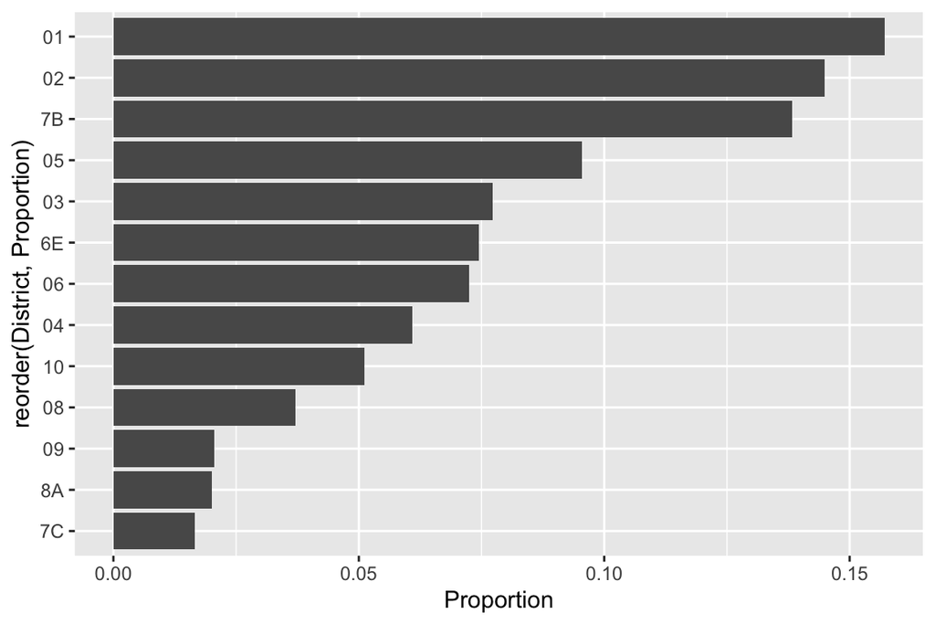

```r
tb <- table(D$Is.Orphan.,D$District.Code)
tbc <- tb[2,]/(tb[2,]+tb[1,])
tbdf <- data.frame(District = names(tbc),
                   Proportion = tbc)
ggplot(tbdf,
       aes(reorder(District, Proportion),
           Proportion)) +
  geom_col() +
  coord_flip()
```

Let’s start fixing effects to understand those big geographic coefficients + differences.

```r
m1f <- feglm(Is.Orphan. ~
               API.Depth +
               Cost.Calculation +
               age +
               inactiveTotalMonths +
               inspectionCount +
               violationCount +
               Org.Type +
               Mailing.Address.State +
               FA.Option +
               FA.Amount +
               nOperators +
               # totprod +
               # sumOil +
               # sumGas +
               Firms.current +
               Average.Weekly.Wage.current +
               Unemployment.Rate.current +
               Population.current +
               Population.Change.current +
               # wti.price.current +
               # ng.price.current +
               interest.rate.current +
               interest.rate.change.current +
               # wti.price.3 +
               # ng.price.3 +
               # wti.price.6 +
               # ng.price.6 +
               # wti.price.12 +
               # ng.price.12 +
               # wti.price.18 +
               # ng.price.18 +
               # wti.price.24 +
               # ng.price.24 +
               interest.rate.12 +
               interest.rate.change.12 +
               interest.rate.18 +
               interest.rate.change.18 +
               interest.rate.24 +
               interest.rate.change.24 +
               # wti.price.3p +
               # ng.price.3p +
               # wti.price.6p +
               # ng.price.6p +
               # wti.price.12p +
               # ng.price.12p +
               normcommod.current +
               normcommod.3 +
               normcommod.6 +
               normcommod.12 +
               normcommod.18 +
               normcommod.24 +
               normcommod.3p +
               normcommod.6p +
               normcommod.12p +
               interest.rate.6p +
               interest.rate.change.6p +
               interest.rate.12p +
               interest.rate.change.12p +
               Firms.12 +
               Average.Weekly.Wage.12 +
               Unemployment.Rate.12 +
               Population.12 +
               Population.Change.12 +
               Firms.24 +
               Average.Weekly.Wage.24 +
               Unemployment.Rate.24 +
               Population.24 +
               Population.Change.24 +
               Firms.12p +
               Average.Weekly.Wage.12p +
               Unemployment.Rate.12p +
               Population.12p +
               Population.Change.12p +
               orgAge |

               District.Code +
               O.G.Code +
               Water.Land.Code +
               completionYear |

               District.Code,
             data = D,
             family = binomial(link="logit"))
summary(m1f)
```

```
## binomial - logit link
##
## Is.Orphan. ~ API.Depth + Cost.Calculation + age + inactiveTotalMonths +
##     inspectionCount + violationCount + Org.Type + Mailing.Address.State +
##     FA.Option + FA.Amount + nOperators + Firms.current + Average.Weekly.Wage.current +
##     Unemployment.Rate.current + Population.current + Population.Change.current +
##     interest.rate.current + interest.rate.change.current + interest.rate.12 +
##     interest.rate.change.12 + interest.rate.18 + interest.rate.change.18 +
##     interest.rate.24 + interest.rate.change.24 + normcommod.current +
##     normcommod.3 + normcommod.6 + normcommod.12 + normcommod.18 +
##     normcommod.24 + normcommod.3p + normcommod.6p + normcommod.12p +
##     interest.rate.6p + interest.rate.change.6p + interest.rate.12p +
##     interest.rate.change.12p + Firms.12 + Average.Weekly.Wage.12 +
##     Unemployment.Rate.12 + Population.12 + Population.Change.12 +
##     Firms.24 + Average.Weekly.Wage.24 + Unemployment.Rate.24 +
##     Population.24 + Population.Change.24 + Firms.12p + Average.Weekly.Wage.12p +
##     Unemployment.Rate.12p + Population.12p + Population.Change.12p +
##     orgAge | District.Code + O.G.Code + Water.Land.Code + completionYear |
##     District.Code
##
## Estimates:
##                                                    Estimate Std. error z value
## API.Depth                                         2.957e-05  2.109e-05   1.402
## Cost.Calculation                                 -8.960e-06  1.747e-06  -5.129
## age                                               7.479e-02  6.601e-02   1.133
## inactiveTotalMonths                               6.917e-03  7.252e-04   9.538
## inspectionCount                                  -6.418e-02  9.266e-03  -6.926
## violationCount                                    4.135e-01  1.254e-02  32.967
## Org.TypeESTATE                                   -1.162e+01  1.034e+02  -0.112
## Org.TypeJOINT VENTURE                            -1.599e+00  6.647e-01  -2.405
## Org.TypeLIMITED LIAB COMPANY                     -6.114e-01  4.716e-02 -12.965
## Org.TypeLIMITED PARTNERSHIP                      -9.754e-01  1.257e-01  -7.760
## Org.TypePARTNERSHIP                               1.420e+00  1.232e-01  11.527
## Org.TypeSOLE PROPRIETORSHIP                       9.058e-01  6.654e-02  13.613
## Org.TypeTRUST                                    -1.334e-02  3.725e-01  -0.036
## Org.TypeOTHER                                    -4.526e+00  7.206e-01  -6.282
## Mailing.Address.StateTX                          -4.432e-01  5.426e-02  -8.167
## FA.OptionOPTION 1 (PER WELL FINANCIAL ASSURANCE) -4.486e+00  3.037e-01 -14.772
## FA.OptionOPTION 2 (BLANKET FINANCIAL ASSURANCE)  -4.487e+00  2.601e-01 -17.250
## FA.OptionOPTION-3                                -1.176e+00  4.838e-01  -2.431
```

[output cut: 103 more lines]

```
## Unemployment.Rate.12p                             0.005290 **
## Population.12p                                    0.305236
## Population.Change.12p                             0.004011 **
## orgAge                                             < 2e-16 ***
## ---
## Signif. codes:  0 '***' 0.001 '**' 0.01 '*' 0.05 '.' 0.1 ' ' 1
##
## residual deviance= 20959.98,
## null deviance= 40532.65,
## n= 84710, l= [13, 2, 3, 92]
##
## ( 12171 observation(s) deleted due to missingness )
## ( 84 observation(s) deleted due to perfect classification )
##
## Number of Fisher Scoring Iterations: 11
```

And just for reference, to make sure we’re not overfitting off the bat, let’s manually drop some of those vars (mostly controls and redundancies) as a means of variable selection:

```r
m2f <- feglm(Is.Orphan. ~
               API.Depth +
               age +
               inactiveTotalMonths +
               inspectionCount +
               violationCount +
               Org.Type +
               Mailing.Address.State +
               FA.Amount +
               nOperators +
               orgAge |

               District.Code +
               O.G.Code +
               Water.Land.Code +
               completionYear |

               District.Code,
             data = D,
             family = binomial(link="logit"))
summary(m2f)
```

```
## binomial - logit link
##
## Is.Orphan. ~ API.Depth + age + inactiveTotalMonths + inspectionCount +
##     violationCount + Org.Type + Mailing.Address.State + FA.Amount +
##     nOperators + orgAge | District.Code + O.G.Code + Water.Land.Code +
##     completionYear | District.Code
##
## Estimates:
##                                Estimate Std. error z value Pr(> |z|)
## API.Depth                    -8.052e-05  6.600e-06 -12.200   < 2e-16 ***
## age                           9.082e-02  6.060e-02   1.499     0.134
## inactiveTotalMonths           3.211e-03  2.001e-04  16.050   < 2e-16 ***
## inspectionCount              -7.083e-02  8.871e-03  -7.984  1.41e-15 ***
## violationCount                4.235e-01  1.188e-02  35.648   < 2e-16 ***
## Org.TypeESTATE               -1.227e+01  1.152e+02  -0.107     0.915
## Org.TypeJOINT VENTURE        -1.030e+00  5.558e-01  -1.852     0.064 .
## Org.TypeLIMITED LIAB COMPANY -7.779e-01  4.235e-02 -18.369   < 2e-16 ***
## Org.TypeLIMITED PARTNERSHIP  -1.312e+00  1.231e-01 -10.653   < 2e-16 ***
## Org.TypePARTNERSHIP           1.358e+00  1.146e-01  11.846   < 2e-16 ***
## Org.TypeSOLE PROPRIETORSHIP   8.754e-01  6.107e-02  14.333   < 2e-16 ***
## Org.TypeTRUST                -5.275e-02  3.497e-01  -0.151     0.880
## Org.TypeOTHER                -6.588e-01  6.506e-01  -1.013     0.311
## Mailing.Address.StateTX      -3.582e-01  4.989e-02  -7.179  7.01e-13 ***
## FA.Amount                    -1.129e-05  2.252e-07 -50.123   < 2e-16 ***
## nOperators                   -1.614e-01  8.680e-03 -18.594   < 2e-16 ***
## orgAge                       -7.200e-02  2.072e-03 -34.741   < 2e-16 ***
## ---
## Signif. codes:  0 '***' 0.001 '**' 0.01 '*' 0.05 '.' 0.1 ' ' 1
##
## residual deviance= 24921.31,
## null deviance= 43590.36,
## n= 93967, l= [13, 2, 4, 92]
##
## ( 2370 observation(s) deleted due to missingness )
## ( 628 observation(s) deleted due to perfect classification )
##
## Number of Fisher Scoring Iterations: 12
```

Okay. So it seems like there might be something there—looks like there’s relevant variance both within and between regions—but it’s important not to jump to conclusions. Right now, given no other information, we might say that wells considered abandoned (not merely inactive) have been inactive for longer, are more likely to be operated by sole proprietors, and have more violations on the books. Their operators are also younger and more likely to have mailing addresses outside of TX.  
At any rate, we’ve got a relatively large *n* and a relatively small difference in the underlying distributions we looked at (along with some correlated columns), so we want to make sure these effects are real.  
Ultimately, we’re going to treat this effort as a kind of prediction task, but our assumption is that *some small percentage of our training examples are mislabeled*. (These cases represent the situation in which we’re interested: that in which the state has not yet categorized an inactive well as abandoned, but our model thinks otherwise.) That is, we’re going to try to build a good classifier, cross-validating and testing along the way, but at the end, we’re going to take a close look at the model’s “false positives” (in the eyes of the state) and ask what differentiates them from true positives and true negatives.